# Analysis CoNNAR - f0 and articulation rate

Tom Offrede

# Notes to understand the analysis

- `confederate` refers to each individual confederate (B1, B2, C1-a, C1-b)
- `confederate type` refers to whether a confederate is an L1 or L2 speaker
- **Synchrony** refers to how a speaker changes their speech in accordance with the speech of the interlocutor: e.g. both produce higher f0, or both produce lower f0 – here there is no approximation between the values of the interlocutors. This is translated into our models below as `speaker's feature ~ interlocutor's feature`. When evaluating if synchrony is affected by the confederate’s proficiency, we add an interaction: `speaker's feature ~ interlocutor's feature : confederate's proficiency`. (Proficiency here can refer to either `confederate type`, i.e. L1 vs L2, or `accent rating`.)
- **Convergence** refers to increasing similarity between the two speakers’ values over time. In our models, it’s translated as `difference in features ~ turn`. Here, `turn` indicates the passage of time in the conversation. We measure influence of confederate’s proficiency in the same way as for synchrony (with an interaction).
- **Register adaptation** below refers to the participants changing their articulation rate depending on who they’re talking to: `speaker's feature ~ confederate's proficiency`.

# Summary of results

## Articulation rate

[output not shown]

## f0 mean

| Type of adapatation | Did it occur overall? | Confederate effect? |
| --- | --- | --- |
| Synchrony | yes | no |
| Convergence | yes | slightly stronger convergence to **L2** |

## f0 median

| Type of adapatation | Did it occur overall? | Confederate effect? |
| --- | --- | --- |
| Synchrony | yes | no |
| Convergence | yes | no |

## f0 SD

| Type of adapatation | Did it occur overall? | Confederate effect? |
| --- | --- | --- |
| Synchrony | no | no |
| Convergence | marginally | no |

## f0 IQR

| Type of adapatation | Did it occur overall? | Confederate effect? |
| --- | --- | --- |
| Synchrony | no | no |
| Convergence | yes | no |

# Articulation rate

## Difference between confederates

### Confederate type

Most L2 confederates spoke slower than L1 confederates. Only one of the C1 confederates did not speak slower than L1 speakers, and the other C1 confederate’s difference was also smaller. The B2 confederate spoke the slowest.

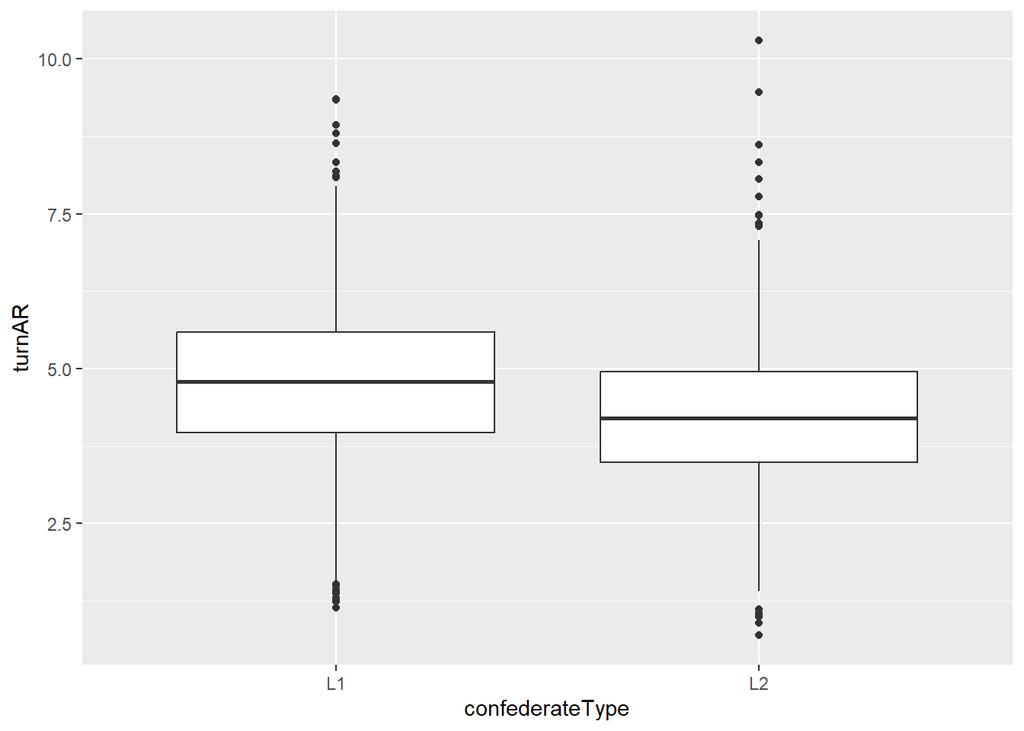

```r
ggplot(dat |> filter(role=="confederate"), aes(confederateType, turnAR))+
  geom_boxplot()
```

```r
dat$confederate <- relevel(dat$confederate, ref="L1")
summary(lmer(turnAR ~ confederate + (1|file), dat |> filter(role=="confederate")))
```

```
## Linear mixed model fit by REML. t-tests use Satterthwaite's method [
## lmerModLmerTest]
## Formula: turnAR ~ confederate + (1 | file)
##    Data: filter(dat, role == "confederate")
##
## REML criterion at convergence: 6131.5
##
## Scaled residuals:
##     Min      1Q  Median      3Q     Max
## -2.9837 -0.5475  0.0493  0.6184  4.8569
##
## Random effects:
##  Groups   Name        Variance Std.Dev.
##  file     (Intercept) 0.07658  0.2767
##  Residual             1.56762  1.2520
## Number of obs: 1849, groups:  file, 40
##
## Fixed effects:
##                 Estimate Std. Error       df t value Pr(>|t|)
## (Intercept)      4.73426    0.07397 34.29967  64.006  < 2e-16 ***
## confederateC1-a -0.34190    0.16585 34.83996  -2.062  0.04678 *
## confederateC1-b -0.20189    0.16762 36.33216  -1.204  0.23621
## confederateL2B1 -0.47582    0.16929 37.76533  -2.811  0.00779 **
## confederateL2B2 -0.94230    0.16915 37.38003  -5.571 2.32e-06 ***
## ---
## Signif. codes:  0 '***' 0.001 '**' 0.01 '*' 0.05 '.' 0.1 ' ' 1
##
## Correlation of Fixed Effects:
##             (Intr) confdrtC1- cnfdrtC1-b cnL2B1
## confedrtC1- -0.446
## confdrtC1-b -0.441  0.197
## confdrtL2B1 -0.437  0.195      0.193
## confdrtL2B2 -0.437  0.195      0.193      0.191
```

```r
summary(lmer(turnAR ~ confederateType + (1|file), dat |> filter(role=="confederate")))
```

```
## Linear mixed model fit by REML. t-tests use Satterthwaite's method [
## lmerModLmerTest]
## Formula: turnAR ~ confederateType + (1 | file)
##    Data: filter(dat, role == "confederate")
##
## REML criterion at convergence: 6139.3
##
## Scaled residuals:
##     Min      1Q  Median      3Q     Max
## -2.9931 -0.5496  0.0455  0.6148  4.8636
##
## Random effects:
##  Groups   Name        Variance Std.Dev.
##  file     (Intercept) 0.1072   0.3274
##  Residual             1.5677   1.2521
## Number of obs: 1849, groups:  file, 40
##
## Fixed effects:
##                   Estimate Std. Error      df t value Pr(>|t|)
## (Intercept)         4.7360     0.0837 37.2643  56.583  < 2e-16 ***
## confederateTypeL2  -0.4892     0.1193 38.4223  -4.102 0.000206 ***
## ---
## Signif. codes:  0 '***' 0.001 '**' 0.01 '*' 0.05 '.' 0.1 ' ' 1
##
## Correlation of Fixed Effects:
##             (Intr)
## cnfdrtTypL2 -0.702
```

### Accent ratings

The higher the accent rating, the slower the speech.

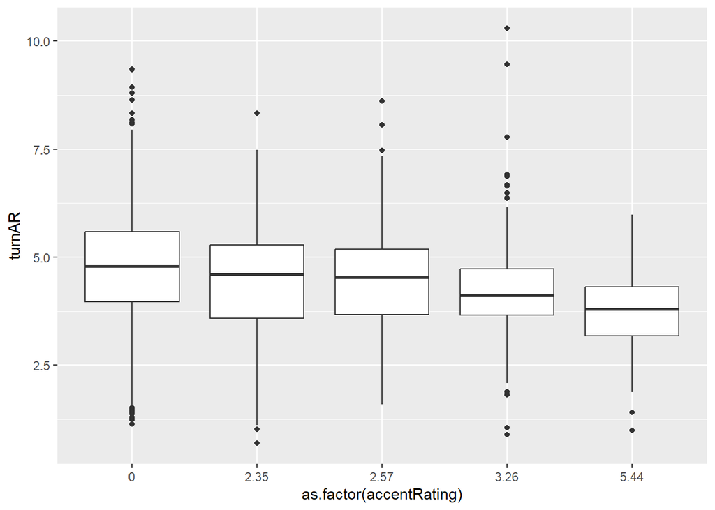

```r
ggplot(dat |> filter(role=="confederate"), aes(as.factor(accentRating), turnAR))+
  geom_boxplot()
```

```r
summary(lmer(turnAR ~ accentRatingc + (1|file), dat |> filter(role=="confederate")))
```

```
## Linear mixed model fit by REML. t-tests use Satterthwaite's method [
## lmerModLmerTest]
## Formula: turnAR ~ accentRatingc + (1 | file)
##    Data: filter(dat, role == "confederate")
##
## REML criterion at convergence: 6131.7
##
## Scaled residuals:
##     Min      1Q  Median      3Q     Max
## -2.9882 -0.5478  0.0478  0.6152  4.8621
##
## Random effects:
##  Groups   Name        Variance Std.Dev.
##  file     (Intercept) 0.0743   0.2726
##  Residual             1.5675   1.2520
## Number of obs: 1849, groups:  file, 40
##
## Fixed effects:
##               Estimate Std. Error       df t value Pr(>|t|)
## (Intercept)    4.50842    0.05230 38.74280  86.198  < 2e-16 ***
## accentRatingc -0.15928    0.02756 39.88819  -5.779 9.75e-07 ***
## ---
## Signif. codes:  0 '***' 0.001 '**' 0.01 '*' 0.05 '.' 0.1 ' ' 1
##
## Correlation of Fixed Effects:
##             (Intr)
## accentRtngc -0.043
```

## Synchrony

The model below shows that the participants don’t synchronize to the confederate.

```r
summary(m0 <- lmer(turnAR ~ prevARc + (1|file), dat |> filter(role=="participant")))
```

```
## Linear mixed model fit by REML. t-tests use Satterthwaite's method [
## lmerModLmerTest]
## Formula: turnAR ~ prevARc + (1 | file)
##    Data: filter(dat, role == "participant")
##
## REML criterion at convergence: 5428.4
##
## Scaled residuals:
##     Min      1Q  Median      3Q     Max
## -3.4025 -0.6219  0.0311  0.6083  5.3036
##
## Random effects:
##  Groups   Name        Variance Std.Dev.
##  file     (Intercept) 0.3467   0.5888
##  Residual             1.4351   1.1979
## Number of obs: 1665, groups:  file, 40
##
## Fixed effects:
##              Estimate Std. Error        df t value Pr(>|t|)
## (Intercept) 4.849e+00  9.791e-02 3.935e+01  49.520   <2e-16 ***
## prevARc     1.024e-02  2.354e-02 1.653e+03   0.435    0.664
## ---
## Signif. codes:  0 '***' 0.001 '**' 0.01 '*' 0.05 '.' 0.1 ' ' 1
##
## Correlation of Fixed Effects:
##         (Intr)
## prevARc 0.050
```

### Confederate effect

And they don’t synchronize regardless of who the confederate is. Considering accent rating instead of `confederate type` also didn’t bring out any effects.

```r
summary(m1 <- lmer(turnAR ~ prevARc : confederateType + (1|file), dat |> filter(role=="participant")))
```

```
## Linear mixed model fit by REML. t-tests use Satterthwaite's method [
## lmerModLmerTest]
## Formula: turnAR ~ prevARc:confederateType + (1 | file)
##    Data: filter(dat, role == "participant")
##
## REML criterion at convergence: 5432.5
##
## Scaled residuals:
##     Min      1Q  Median      3Q     Max
## -3.4106 -0.6201  0.0306  0.6105  5.3077
##
## Random effects:
##  Groups   Name        Variance Std.Dev.
##  file     (Intercept) 0.3454   0.5877
##  Residual             1.4360   1.1983
## Number of obs: 1665, groups:  file, 40
##
## Fixed effects:
##                            Estimate Std. Error        df t value Pr(>|t|)
## (Intercept)               4.851e+00  9.804e-02 3.966e+01  49.480   <2e-16 ***
## prevARc:confederateTypeL1 4.860e-03  3.003e-02 1.645e+03   0.162    0.871
## prevARc:confederateTypeL2 1.886e-02  3.799e-02 1.659e+03   0.496    0.620
## ---
## Signif. codes:  0 '***' 0.001 '**' 0.01 '*' 0.05 '.' 0.1 ' ' 1
##
## Correlation of Fixed Effects:
##             (Intr) pAR:TL1
## prvARc:cTL1 -0.007
## prvARc:cTL2  0.089 -0.001
```

```r
summary(m2 <- lmer(turnAR ~ prevARc : accentRatingc + (1|file), dat |> filter(role=="participant")))
```

```
## Linear mixed model fit by REML. t-tests use Satterthwaite's method [
## lmerModLmerTest]
## Formula: turnAR ~ prevARc:accentRatingc + (1 | file)
##    Data: filter(dat, role == "participant")
##
## REML criterion at convergence: 5429.4
##
## Scaled residuals:
##     Min      1Q  Median      3Q     Max
## -3.4367 -0.6189  0.0294  0.6095  5.3249
##
## Random effects:
##  Groups   Name        Variance Std.Dev.
##  file     (Intercept) 0.3452   0.5875
##  Residual             1.4352   1.1980
## Number of obs: 1665, groups:  file, 40
##
## Fixed effects:
##                        Estimate Std. Error        df t value Pr(>|t|)
## (Intercept)           4.850e+00  9.799e-02 3.958e+01  49.501   <2e-16 ***
## prevARc:accentRatingc 6.114e-03  1.398e-02 1.658e+03   0.437    0.662
## ---
## Signif. codes:  0 '***' 0.001 '**' 0.01 '*' 0.05 '.' 0.1 ' ' 1
##
## Correlation of Fixed Effects:
##             (Intr)
## prvARc:ccnR 0.088
```

```r
anova(m0, m1)
```

```
## refitting model(s) with ML (instead of REML)
```

```
## Data: filter(dat, role == "participant")
## Models:
## m0: turnAR ~ prevARc + (1 | file)
## m1: turnAR ~ prevARc:confederateType + (1 | file)
##    npar    AIC    BIC  logLik deviance  Chisq Df Pr(>Chisq)
## m0    4 5427.9 5449.6 -2709.9   5419.9
## m1    5 5429.8 5456.9 -2709.9   5419.8 0.0868  1     0.7683
```

```r
anova(m0, m2)
```

```
## refitting model(s) with ML (instead of REML)
```

```
## Data: filter(dat, role == "participant")
## Models:
## m0: turnAR ~ prevARc + (1 | file)
## m2: turnAR ~ prevARc:accentRatingc + (1 | file)
##    npar    AIC    BIC  logLik deviance  Chisq Df Pr(>Chisq)
## m0    4 5427.9 5449.6 -2709.9   5419.9
## m2    4 5427.9 5449.5 -2709.9   5419.9 0.0058  0
```

## Convergence

Participants don’t converge on articulation rate to the confederates (i.e., the difference between their features doesn’t change across time).

```r
summary(m0 <- lmer(artRateDiff ~ turn + (1|file), dat |> filter(role=="participant")))
```

```
## Linear mixed model fit by REML. t-tests use Satterthwaite's method [
## lmerModLmerTest]
## Formula: artRateDiff ~ turn + (1 | file)
##    Data: filter(dat, role == "participant")
##
## REML criterion at convergence: 5161.2
##
## Scaled residuals:
##     Min      1Q  Median      3Q     Max
## -1.6233 -0.7608 -0.2036  0.5656  5.7350
##
## Random effects:
##  Groups   Name        Variance Std.Dev.
##  file     (Intercept) 0.05553  0.2357
##  Residual             1.25764  1.1214
## Number of obs: 1665, groups:  file, 40
##
## Fixed effects:
##              Estimate Std. Error        df t value Pr(>|t|)
## (Intercept) 1.434e+00  6.523e-02 1.491e+02  21.990   <2e-16 ***
## turn        1.993e-03  1.784e-03 1.657e+03   1.118    0.264
## ---
## Signif. codes:  0 '***' 0.001 '**' 0.01 '*' 0.05 '.' 0.1 ' ' 1
##
## Correlation of Fixed Effects:
##      (Intr)
## turn -0.701
```

### Confederate effect

```r
summary(m1 <- lmer(artRateDiff ~ turn : confederateType + (1|file), dat |> filter(role=="participant")))
```

```
## Linear mixed model fit by REML. t-tests use Satterthwaite's method [
## lmerModLmerTest]
## Formula: artRateDiff ~ turn:confederateType + (1 | file)
##    Data: filter(dat, role == "participant")
##
## REML criterion at convergence: 5169.8
##
## Scaled residuals:
##     Min      1Q  Median      3Q     Max
## -1.6333 -0.7667 -0.1991  0.5654  5.7373
##
## Random effects:
##  Groups   Name        Variance Std.Dev.
##  file     (Intercept) 0.05423  0.2329
##  Residual             1.25773  1.1215
## Number of obs: 1665, groups:  file, 40
##
## Fixed effects:
##                         Estimate Std. Error        df t value Pr(>|t|)
## (Intercept)            1.442e+00  6.526e-02 1.519e+02  22.091   <2e-16 ***
## turn:confederateTypeL1 3.162e-03  2.023e-03 8.261e+02   1.563    0.118
## turn:confederateTypeL2 2.243e-05  2.414e-03 6.458e+02   0.009    0.993
## ---
## Signif. codes:  0 '***' 0.001 '**' 0.01 '*' 0.05 '.' 0.1 ' ' 1
##
## Correlation of Fixed Effects:
##             (Intr) tr:TL1
## trn:cnfdTL1 -0.574
## trn:cnfdTL2 -0.580  0.333
```

```r
summary(m2 <- lmer(artRateDiff ~ turn : accentRatingc + (1|file), dat |> filter(role=="participant")))
```

```
## Linear mixed model fit by REML. t-tests use Satterthwaite's method [
## lmerModLmerTest]
## Formula: artRateDiff ~ turn:accentRatingc + (1 | file)
##    Data: filter(dat, role == "participant")
##
## REML criterion at convergence: 5159.2
##
## Scaled residuals:
##     Min      1Q  Median      3Q     Max
## -1.6324 -0.7638 -0.1902  0.5545  5.7329
##
## Random effects:
##  Groups   Name        Variance Std.Dev.
##  file     (Intercept) 0.05006  0.2237
##  Residual             1.25664  1.1210
## Number of obs: 1665, groups:  file, 40
##
## Fixed effects:
##                      Estimate Std. Error         df t value Pr(>|t|)
## (Intercept)         1.484e+00  4.502e-02  4.020e+01  32.952   <2e-16 ***
## turn:accentRatingc -1.600e-03  6.999e-04  1.340e+02  -2.286   0.0238 *
## ---
## Signif. codes:  0 '***' 0.001 '**' 0.01 '*' 0.05 '.' 0.1 ' ' 1
##
## Correlation of Fixed Effects:
##             (Intr)
## trn:ccntRtn 0.020
```

```r
anova(m0, m1)
```

```
## refitting model(s) with ML (instead of REML)
```

```
## Data: filter(dat, role == "participant")
## Models:
## m0: artRateDiff ~ turn + (1 | file)
## m1: artRateDiff ~ turn:confederateType + (1 | file)
##    npar    AIC    BIC  logLik deviance  Chisq Df Pr(>Chisq)
## m0    4 5154.1 5175.8 -2573.1   5146.1
## m1    5 5154.6 5181.7 -2572.3   5144.6 1.5062  1     0.2197
```

```r
anova(m0, m2)
```

```
## refitting model(s) with ML (instead of REML)
```

```
## Data: filter(dat, role == "participant")
## Models:
## m0: artRateDiff ~ turn + (1 | file)
## m2: artRateDiff ~ turn:accentRatingc + (1 | file)
##    npar    AIC    BIC  logLik deviance  Chisq Df Pr(>Chisq)
## m0    4 5154.1 5175.8 -2573.1   5146.1
## m2    4 5150.2 5171.8 -2571.1   5142.2 3.9312  0
```

## Register adaptation

Participants did not speak differently to L1 vs L2 speakers.

```r
summary(lmer(turnAR ~ confederateType + (1|file), dat |> filter(role=="participant")))
```

```
## Linear mixed model fit by REML. t-tests use Satterthwaite's method [
## lmerModLmerTest]
## Formula: turnAR ~ confederateType + (1 | file)
##    Data: filter(dat, role == "participant")
##
## REML criterion at convergence: 5952.3
##
## Scaled residuals:
##     Min      1Q  Median      3Q     Max
## -3.3948 -0.6170  0.0268  0.6104  5.3152
##
## Random effects:
##  Groups   Name        Variance Std.Dev.
##  file     (Intercept) 0.344    0.5865
##  Residual             1.433    1.1970
## Number of obs: 1830, groups:  file, 40
##
## Fixed effects:
##                   Estimate Std. Error      df t value Pr(>|t|)
## (Intercept)         4.9110     0.1370 37.8135  35.858   <2e-16 ***
## confederateTypeL2  -0.1231     0.1940 38.0983  -0.634     0.53
## ---
## Signif. codes:  0 '***' 0.001 '**' 0.01 '*' 0.05 '.' 0.1 ' ' 1
##
## Correlation of Fixed Effects:
##             (Intr)
## cnfdrtTypL2 -0.706
```

```r
summary(lmer(turnAR ~ accentRatingc + (1|file), dat |> filter(role=="participant")))
```

```
## Linear mixed model fit by REML. t-tests use Satterthwaite's method [
## lmerModLmerTest]
## Formula: turnAR ~ accentRatingc + (1 | file)
##    Data: filter(dat, role == "participant")
##
## REML criterion at convergence: 5954
##
## Scaled residuals:
##     Min      1Q  Median      3Q     Max
## -3.3956 -0.6179  0.0272  0.6088  5.3137
##
## Random effects:
##  Groups   Name        Variance Std.Dev.
##  file     (Intercept) 0.3341   0.578
##  Residual             1.4328   1.197
## Number of obs: 1830, groups:  file, 40
##
## Fixed effects:
##               Estimate Std. Error       df t value Pr(>|t|)
## (Intercept)    4.85660    0.09591 38.04314  50.634   <2e-16 ***
## accentRatingc -0.06007    0.05033 38.61495  -1.194     0.24
## ---
## Signif. codes:  0 '***' 0.001 '**' 0.01 '*' 0.05 '.' 0.1 ' ' 1
##
## Correlation of Fixed Effects:
##             (Intr)
## accentRtngc -0.059
```

# f0 mean

## Synchrony

Participants seem to synchronize on f0 mean to the confederate.

```r
summary(m0 <- lmer(f0meanz ~ prevf0meanC + (1|file), dat |> filter(role == "participant")))
```

```
## Linear mixed model fit by REML. t-tests use Satterthwaite's method [
## lmerModLmerTest]
## Formula: f0meanz ~ prevf0meanC + (1 | file)
##    Data: filter(dat, role == "participant")
##
## REML criterion at convergence: 5500.6
##
## Scaled residuals:
##     Min      1Q  Median      3Q     Max
## -2.6129 -0.6327 -0.1918  0.4420  4.9684
##
## Random effects:
##  Groups   Name        Variance Std.Dev.
##  file     (Intercept) 0.03902  0.1975
##  Residual             1.20963  1.0998
## Number of obs: 1802, groups:  file, 40
##
## Fixed effects:
##              Estimate Std. Error        df t value Pr(>|t|)
## (Intercept) 3.672e-02  4.078e-02 3.722e+01   0.900    0.374
## prevf0meanC 1.605e-01  2.351e-02 1.777e+03   6.827 1.19e-11 ***
## ---
## Signif. codes:  0 '***' 0.001 '**' 0.01 '*' 0.05 '.' 0.1 ' ' 1
##
## Correlation of Fixed Effects:
##             (Intr)
## prevf0meanC 0.001
```

### Confederate effect

The model without `confederate type` is better than the one with, and there is no effect with `accent rating` So participants do **not** synchronize differently to L1 vs L2 confederates.

```r
summary(m1 <- lmer(f0meanz ~ prevf0meanC : confederateType + (1|file), dat |> filter(role == "participant")))
```

```
## Linear mixed model fit by REML. t-tests use Satterthwaite's method [
## lmerModLmerTest]
## Formula: f0meanz ~ prevf0meanC:confederateType + (1 | file)
##    Data: filter(dat, role == "participant")
##
## REML criterion at convergence: 5504.4
##
## Scaled residuals:
##     Min      1Q  Median      3Q     Max
## -2.6436 -0.6332 -0.1917  0.4411  4.9563
##
## Random effects:
##  Groups   Name        Variance Std.Dev.
##  file     (Intercept) 0.03885  0.1971
##  Residual             1.21007  1.1000
## Number of obs: 1802, groups:  file, 40
##
## Fixed effects:
##                                Estimate Std. Error        df t value Pr(>|t|)
## (Intercept)                   3.622e-02  4.074e-02 3.720e+01   0.889     0.38
## prevf0meanC:confederateTypeL1 1.430e-01  3.498e-02 1.785e+03   4.088 4.54e-05
## prevf0meanC:confederateTypeL2 1.750e-01  3.176e-02 1.768e+03   5.508 4.16e-08
##
## (Intercept)
## prevf0meanC:confederateTypeL1 ***
## prevf0meanC:confederateTypeL2 ***
## ---
## Signif. codes:  0 '***' 0.001 '**' 0.01 '*' 0.05 '.' 0.1 ' ' 1
##
## Correlation of Fixed Effects:
##             (Intr) p0C:TL1
## prvf0mC:TL1  0.014
## prvf0mC:TL2 -0.011  0.000
```

```r
summary(m2 <- lmer(f0meanz ~ prevf0meanC : accentRatingc + (1|file), dat |> filter(role == "participant")))
```

```
## Linear mixed model fit by REML. t-tests use Satterthwaite's method [
## lmerModLmerTest]
## Formula: f0meanz ~ prevf0meanC:accentRatingc + (1 | file)
##    Data: filter(dat, role == "participant")
##
## REML criterion at convergence: 5546.5
##
## Scaled residuals:
##     Min      1Q  Median      3Q     Max
## -2.9105 -0.6373 -0.1923  0.4396  5.0016
##
## Random effects:
##  Groups   Name        Variance Std.Dev.
##  file     (Intercept) 0.05034  0.2244
##  Residual             1.23608  1.1118
## Number of obs: 1802, groups:  file, 40
##
## Fixed effects:
##                            Estimate Std. Error        df t value Pr(>|t|)
## (Intercept)               3.654e-02  4.431e-02 3.759e+01   0.825    0.415
## prevf0meanC:accentRatingc 1.277e-02  1.208e-02 1.800e+03   1.057    0.291
##
## Correlation of Fixed Effects:
##             (Intr)
## prvf0mnC:cR -0.002
```

```r
anova(m0, m1)
```

```
## refitting model(s) with ML (instead of REML)
```

```
## Data: filter(dat, role == "participant")
## Models:
## m0: f0meanz ~ prevf0meanC + (1 | file)
## m1: f0meanz ~ prevf0meanC:confederateType + (1 | file)
##    npar    AIC    BIC  logLik deviance  Chisq Df Pr(>Chisq)
## m0    4 5498.4 5520.4 -2745.2   5490.4
## m1    5 5499.9 5527.4 -2745.0   5489.9 0.4602  1     0.4975
```

```r
anova(m0, m2)
```

```
## refitting model(s) with ML (instead of REML)
```

```
## Data: filter(dat, role == "participant")
## Models:
## m0: f0meanz ~ prevf0meanC + (1 | file)
## m2: f0meanz ~ prevf0meanC:accentRatingc + (1 | file)
##    npar    AIC    BIC  logLik deviance Chisq Df Pr(>Chisq)
## m0    4 5498.4 5520.4 -2745.2   5490.4
## m2    4 5543.1 5565.1 -2767.6   5535.1     0  0
```

## Convergence

Participants also converge to the confederates.

```r
summary(m0 <- lmer(f0meanDiff ~ turn + (1|file), dat |> filter(role == "participant")))
```

```
## Linear mixed model fit by REML. t-tests use Satterthwaite's method [
## lmerModLmerTest]
## Formula: f0meanDiff ~ turn + (1 | file)
##    Data: filter(dat, role == "participant")
##
## REML criterion at convergence: 5083.2
##
## Scaled residuals:
##     Min      1Q  Median      3Q     Max
## -1.2680 -0.7035 -0.2817  0.3892  7.6417
##
## Random effects:
##  Groups   Name        Variance Std.Dev.
##  file     (Intercept) 0.01391  0.1180
##  Residual             0.96461  0.9821
## Number of obs: 1802, groups:  file, 40
##
## Fixed effects:
##               Estimate Std. Error         df t value Pr(>|t|)
## (Intercept)  1.233e+00  5.051e-02  2.546e+02   24.41  < 2e-16 ***
## turn        -6.197e-03  1.504e-03  1.641e+03   -4.12 3.97e-05 ***
## ---
## Signif. codes:  0 '***' 0.001 '**' 0.01 '*' 0.05 '.' 0.1 ' ' 1
##
## Correlation of Fixed Effects:
##      (Intr)
## turn -0.807
```

### Confederate effect

`Confederate type` seems to improve the model (lower AIC), but the direction of the effect is the same. It seems that participants converge more to L2 than to L1 speakers though.

```r
summary(m1 <- lmer(f0meanDiff ~ turn : confederateType + (1|file), dat |> filter(role == "participant")))
```

```
## Linear mixed model fit by REML. t-tests use Satterthwaite's method [
## lmerModLmerTest]
## Formula: f0meanDiff ~ turn:confederateType + (1 | file)
##    Data: filter(dat, role == "participant")
##
## REML criterion at convergence: 5088.7
##
## Scaled residuals:
##     Min      1Q  Median      3Q     Max
## -1.2750 -0.7074 -0.2821  0.3920  7.6077
##
## Random effects:
##  Groups   Name        Variance Std.Dev.
##  file     (Intercept) 0.01496  0.1223
##  Residual             0.96171  0.9807
## Number of obs: 1802, groups:  file, 40
##
## Fixed effects:
##                          Estimate Std. Error         df t value Pr(>|t|)
## (Intercept)              1.245909   0.051015 243.365162  24.422  < 2e-16 ***
## turn:confederateTypeL1  -0.004786   0.001628 617.966952  -2.940  0.00341 **
## turn:confederateTypeL2  -0.008992   0.001929 537.694726  -4.661 3.98e-06 ***
## ---
## Signif. codes:  0 '***' 0.001 '**' 0.01 '*' 0.05 '.' 0.1 ' ' 1
##
## Correlation of Fixed Effects:
##             (Intr) tr:TL1
## trn:cnfdTL1 -0.695
## trn:cnfdTL2 -0.689  0.479
```

```r
summary(m2 <- lmer(f0meanDiff ~ turn : accentRating + (1|file), dat |> filter(role == "participant")))
```

```
## Linear mixed model fit by REML. t-tests use Satterthwaite's method [
## lmerModLmerTest]
## Formula: f0meanDiff ~ turn:accentRating + (1 | file)
##    Data: filter(dat, role == "participant")
##
## REML criterion at convergence: 5091.3
##
## Scaled residuals:
##     Min      1Q  Median      3Q     Max
## -1.2347 -0.7008 -0.2740  0.3867  7.5400
##
## Random effects:
##  Groups   Name        Variance Std.Dev.
##  file     (Intercept) 0.0196   0.1400
##  Residual             0.9647   0.9822
## Number of obs: 1802, groups:  file, 40
##
## Fixed effects:
##                     Estimate Std. Error         df t value Pr(>|t|)
## (Intercept)        1.134e+00  3.795e-02  3.767e+01   29.88  < 2e-16 ***
## turn:accentRating -1.716e-03  4.973e-04  1.084e+02   -3.45 0.000799 ***
## ---
## Signif. codes:  0 '***' 0.001 '**' 0.01 '*' 0.05 '.' 0.1 ' ' 1
##
## Correlation of Fixed Effects:
##             (Intr)
## trn:ccntRtn -0.530
```

```r
anova(m0, m1)
```

```
## refitting model(s) with ML (instead of REML)
```

```
## Data: filter(dat, role == "participant")
## Models:
## m0: f0meanDiff ~ turn + (1 | file)
## m1: f0meanDiff ~ turn:confederateType + (1 | file)
##    npar    AIC    BIC  logLik deviance  Chisq Df Pr(>Chisq)
## m0    4 5074.8 5096.8 -2533.4   5066.8
## m1    5 5071.6 5099.1 -2530.8   5061.6 5.2388  1    0.02209 *
## ---
## Signif. codes:  0 '***' 0.001 '**' 0.01 '*' 0.05 '.' 0.1 ' ' 1
```

```r
anova(m0, m2)
```

```
## refitting model(s) with ML (instead of REML)
```

```
## Data: filter(dat, role == "participant")
## Models:
## m0: f0meanDiff ~ turn + (1 | file)
## m2: f0meanDiff ~ turn:accentRating + (1 | file)
##    npar    AIC    BIC  logLik deviance Chisq Df Pr(>Chisq)
## m0    4 5074.8 5096.8 -2533.4   5066.8
## m2    4 5080.8 5102.8 -2536.4   5072.8     0  0
```

# f0 median

## Synchrony

As for f0 mean: participants synchronize to their interlocutors.

```r
summary(m0 <- lmer(f0med ~ prevf0medC + (1|file), dat |> filter(role == "participant")))
```

```
## Linear mixed model fit by REML. t-tests use Satterthwaite's method [
## lmerModLmerTest]
## Formula: f0med ~ prevf0medC + (1 | file)
##    Data: filter(dat, role == "participant")
##
## REML criterion at convergence: 16504.6
##
## Scaled residuals:
##     Min      1Q  Median      3Q     Max
## -4.3397 -0.5489 -0.1687  0.3111  6.8361
##
## Random effects:
##  Groups   Name        Variance Std.Dev.
##  file     (Intercept) 2631     51.29
##  Residual              508     22.54
## Number of obs: 1797, groups:  file, 40
##
## Fixed effects:
##              Estimate Std. Error        df t value Pr(>|t|)
## (Intercept)  165.7761     8.1286   38.9845  20.394  < 2e-16 ***
## prevf0medC     2.9652     0.4724 1757.6827   6.277 4.33e-10 ***
## ---
## Signif. codes:  0 '***' 0.001 '**' 0.01 '*' 0.05 '.' 0.1 ' ' 1
##
## Correlation of Fixed Effects:
##            (Intr)
## prevf0medC 0.001
```

### Confederate effect

`Confederate type` did not improve the model. Participants synchronized on f0 median to the same extent.

```r
summary(m1 <- lmer(f0med ~ prevf0medC : confederateType + (1|file), dat |> filter(role == "participant")))
```

```
## Linear mixed model fit by REML. t-tests use Satterthwaite's method [
## lmerModLmerTest]
## Formula: f0med ~ prevf0medC:confederateType + (1 | file)
##    Data: filter(dat, role == "participant")
##
## REML criterion at convergence: 16502.4
##
## Scaled residuals:
##     Min      1Q  Median      3Q     Max
## -4.3164 -0.5450 -0.1673  0.3093  6.8341
##
## Random effects:
##  Groups   Name        Variance Std.Dev.
##  file     (Intercept) 2631.5   51.30
##  Residual              508.1   22.54
## Number of obs: 1797, groups:  file, 40
##
## Fixed effects:
##                               Estimate Std. Error        df t value Pr(>|t|)
## (Intercept)                   165.7842     8.1293   38.9845  20.393  < 2e-16
## prevf0medC:confederateTypeL1    3.2839     0.6836 1756.3345   4.804 1.69e-06
## prevf0medC:confederateTypeL2    2.6739     0.6536 1756.9941   4.091 4.49e-05
##
## (Intercept)                  ***
## prevf0medC:confederateTypeL1 ***
## prevf0medC:confederateTypeL2 ***
## ---
## Signif. codes:  0 '***' 0.001 '**' 0.01 '*' 0.05 '.' 0.1 ' ' 1
##
## Correlation of Fixed Effects:
##             (Intr) p0C:TL1
## prvf0mC:TL1  0.002
## prvf0mC:TL2 -0.001  0.000
```

```r
summary(m2 <- lmer(f0med ~ prevf0medC : accentRatingc + (1|file), dat |> filter(role == "participant")))
```

```
## Linear mixed model fit by REML. t-tests use Satterthwaite's method [
## lmerModLmerTest]
## Formula: f0med ~ prevf0medC:accentRatingc + (1 | file)
##    Data: filter(dat, role == "participant")
##
## REML criterion at convergence: 16544.8
##
## Scaled residuals:
##     Min      1Q  Median      3Q     Max
## -4.4924 -0.5432 -0.1766  0.3054  6.7529
##
## Random effects:
##  Groups   Name        Variance Std.Dev.
##  file     (Intercept) 2687.0   51.84
##  Residual              519.1   22.78
## Number of obs: 1797, groups:  file, 40
##
## Fixed effects:
##                            Estimate Std. Error         df t value Pr(>|t|)
## (Intercept)               165.74071    8.21447   38.99259   20.18   <2e-16 ***
## prevf0medC:accentRatingc   -0.08233    0.24216 1757.26012   -0.34    0.734
## ---
## Signif. codes:  0 '***' 0.001 '**' 0.01 '*' 0.05 '.' 0.1 ' ' 1
##
## Correlation of Fixed Effects:
##             (Intr)
## prvf0mdC:cR 0.000
```

```r
anova(m0, m1)
```

```
## refitting model(s) with ML (instead of REML)
```

```
## Data: filter(dat, role == "participant")
## Models:
## m0: f0med ~ prevf0medC + (1 | file)
## m1: f0med ~ prevf0medC:confederateType + (1 | file)
##    npar   AIC   BIC  logLik deviance  Chisq Df Pr(>Chisq)
## m0    4 16519 16541 -8255.5    16511
## m1    5 16521 16548 -8255.3    16511 0.4162  1     0.5188
```

```r
anova(m0, m2)
```

```
## refitting model(s) with ML (instead of REML)
```

```
## Data: filter(dat, role == "participant")
## Models:
## m0: f0med ~ prevf0medC + (1 | file)
## m2: f0med ~ prevf0medC:accentRatingc + (1 | file)
##    npar   AIC   BIC  logLik deviance Chisq Df Pr(>Chisq)
## m0    4 16519 16541 -8255.5    16511
## m2    4 16558 16580 -8274.9    16550     0  0
```

## Convergence

Participants converged on f0 median.

```r
summary(m0 <- lmer(f0medDiff ~ turn + (1|file), dat |> filter(role == "participant")))
```

```
## Linear mixed model fit by REML. t-tests use Satterthwaite's method [
## lmerModLmerTest]
## Formula: f0medDiff ~ turn + (1 | file)
##    Data: filter(dat, role == "participant")
##
## REML criterion at convergence: 5521.7
##
## Scaled residuals:
##     Min      1Q  Median      3Q     Max
## -1.1815 -0.6367 -0.2704  0.3282  8.2324
##
## Random effects:
##  Groups   Name        Variance Std.Dev.
##  file     (Intercept) 0.02398  0.1549
##  Residual             1.23784  1.1126
## Number of obs: 1797, groups:  file, 40
##
## Fixed effects:
##               Estimate Std. Error         df t value Pr(>|t|)
## (Intercept)  1.208e+00  5.872e-02  2.341e+02  20.572   <2e-16 ***
## turn        -4.105e-03  1.713e-03  1.693e+03  -2.396   0.0167 *
## ---
## Signif. codes:  0 '***' 0.001 '**' 0.01 '*' 0.05 '.' 0.1 ' ' 1
##
## Correlation of Fixed Effects:
##      (Intr)
## turn -0.789
```

### Confederate effect

`Confederate type` made the model worse.

```r
summary(m1 <- lmer(f0medDiff ~ turn : confederateType + (1|file), dat |> filter(role == "participant")))
```

```
## Linear mixed model fit by REML. t-tests use Satterthwaite's method [
## lmerModLmerTest]
## Formula: f0medDiff ~ turn:confederateType + (1 | file)
##    Data: filter(dat, role == "participant")
##
## REML criterion at convergence: 5532
##
## Scaled residuals:
##     Min      1Q  Median      3Q     Max
## -1.1830 -0.6375 -0.2694  0.3263  8.2258
##
## Random effects:
##  Groups   Name        Variance Std.Dev.
##  file     (Intercept) 0.02492  0.1579
##  Residual             1.23798  1.1126
## Number of obs: 1797, groups:  file, 40
##
## Fixed effects:
##                          Estimate Std. Error         df t value Pr(>|t|)
## (Intercept)              1.210328   0.059254 233.442978  20.426   <2e-16 ***
## turn:confederateTypeL1  -0.003861   0.001872 671.799583  -2.062   0.0396 *
## turn:confederateTypeL2  -0.004600   0.002219 578.924185  -2.073   0.0386 *
## ---
## Signif. codes:  0 '***' 0.001 '**' 0.01 '*' 0.05 '.' 0.1 ' ' 1
##
## Correlation of Fixed Effects:
##             (Intr) tr:TL1
## trn:cnfdTL1 -0.674
## trn:cnfdTL2 -0.670  0.452
```

```r
summary(m2 <- lmer(f0medDiff ~ turn : accentRating + (1|file), dat |> filter(role == "participant")))
```

```
## Linear mixed model fit by REML. t-tests use Satterthwaite's method [
## lmerModLmerTest]
## Formula: f0medDiff ~ turn:accentRating + (1 | file)
##    Data: filter(dat, role == "participant")
##
## REML criterion at convergence: 5528.8
##
## Scaled residuals:
##     Min      1Q  Median      3Q     Max
## -1.1555 -0.6393 -0.2806  0.3248  8.2458
##
## Random effects:
##  Groups   Name        Variance Std.Dev.
##  file     (Intercept) 0.02406  0.1551
##  Residual             1.24119  1.1141
## Number of obs: 1797, groups:  file, 40
##
## Fixed effects:
##                     Estimate Std. Error         df t value Pr(>|t|)
## (Intercept)        1.118e+00  4.264e-02  4.473e+01  26.222   <2e-16 ***
## turn:accentRating -5.227e-04  5.578e-04  1.244e+02  -0.937    0.351
## ---
## Signif. codes:  0 '***' 0.001 '**' 0.01 '*' 0.05 '.' 0.1 ' ' 1
##
## Correlation of Fixed Effects:
##             (Intr)
## trn:ccntRtn -0.531
```

```r
anova(m0, m1)
```

```
## refitting model(s) with ML (instead of REML)
```

```
## Data: filter(dat, role == "participant")
## Models:
## m0: f0medDiff ~ turn + (1 | file)
## m1: f0medDiff ~ turn:confederateType + (1 | file)
##    npar    AIC    BIC  logLik deviance Chisq Df Pr(>Chisq)
## m0    4 5513.9 5535.9 -2753.0   5505.9
## m1    5 5515.8 5543.3 -2752.9   5505.8 0.116  1     0.7335
```

```r
anova(m0, m2)
```

```
## refitting model(s) with ML (instead of REML)
```

```
## Data: filter(dat, role == "participant")
## Models:
## m0: f0medDiff ~ turn + (1 | file)
## m2: f0medDiff ~ turn:accentRating + (1 | file)
##    npar    AIC    BIC  logLik deviance Chisq Df Pr(>Chisq)
## m0    4 5513.9 5535.9 -2753.0   5505.9
## m2    4 5518.8 5540.8 -2755.4   5510.8     0  0
```

# f0 SD

## Synchrony

Participants did not synchronize on f0 SD.

```r
summary(m0 <- lmer(f0sd ~ prevf0sdC + (1|file), dat |> filter(role == "participant")))
```

```
## Linear mixed model fit by REML. t-tests use Satterthwaite's method [
## lmerModLmerTest]
## Formula: f0sd ~ prevf0sdC + (1 | file)
##    Data: filter(dat, role == "participant")
##
## REML criterion at convergence: 18230
##
## Scaled residuals:
##     Min      1Q  Median      3Q     Max
## -2.0846 -0.7554 -0.0750  0.5967  3.5024
##
## Random effects:
##  Groups   Name        Variance Std.Dev.
##  file     (Intercept)  108.2   10.40
##  Residual             1119.4   33.46
## Number of obs: 1843, groups:  file, 40
##
## Fixed effects:
##              Estimate Std. Error        df t value Pr(>|t|)
## (Intercept)   48.7650     1.8261   39.4001  26.705   <2e-16 ***
## prevf0sdC      0.9297     0.7444 1837.2288   1.249    0.212
## ---
## Signif. codes:  0 '***' 0.001 '**' 0.01 '*' 0.05 '.' 0.1 ' ' 1
##
## Correlation of Fixed Effects:
##           (Intr)
## prevf0sdC -0.006
```

### Confederate effect

Adding `confederate` to the model didn’t improve it enough. There was no robust by-confederate effect.

```r
summary(m1 <- lmer(f0sd ~ prevf0sdC : confederateType + (1|file), dat |> filter(role == "participant")))
```

```
## Linear mixed model fit by REML. t-tests use Satterthwaite's method [
## lmerModLmerTest]
## Formula: f0sd ~ prevf0sdC:confederateType + (1 | file)
##    Data: filter(dat, role == "participant")
##
## REML criterion at convergence: 18223.9
##
## Scaled residuals:
##     Min      1Q  Median      3Q     Max
## -2.0570 -0.7522 -0.0758  0.5965  3.4716
##
## Random effects:
##  Groups   Name        Variance Std.Dev.
##  file     (Intercept)  107.8   10.38
##  Residual             1117.9   33.43
## Number of obs: 1843, groups:  file, 40
##
## Fixed effects:
##                              Estimate Std. Error        df t value Pr(>|t|)
## (Intercept)                   48.6606     1.8240   39.5085  26.677   <2e-16 ***
## prevf0sdC:confederateTypeL1    2.3330     1.0562 1837.0457   2.209   0.0273 *
## prevf0sdC:confederateTypeL2   -0.4526     1.0483 1834.2124  -0.432   0.6660
## ---
## Signif. codes:  0 '***' 0.001 '**' 0.01 '*' 0.05 '.' 0.1 ' ' 1
##
## Correlation of Fixed Effects:
##             (Intr) p0C:TL1
## prvf0sC:TL1 -0.026
## prvf0sC:TL2  0.017  0.000
```

```r
summary(m2 <- lmer(f0sd ~ prevf0sdC : accentRatingc + (1|file), dat |> filter(role == "participant")))
```

```
## Linear mixed model fit by REML. t-tests use Satterthwaite's method [
## lmerModLmerTest]
## Formula: f0sd ~ prevf0sdC:accentRatingc + (1 | file)
##    Data: filter(dat, role == "participant")
##
## REML criterion at convergence: 18230
##
## Scaled residuals:
##     Min      1Q  Median      3Q     Max
## -2.0562 -0.7541 -0.0786  0.5983  3.4656
##
## Random effects:
##  Groups   Name        Variance Std.Dev.
##  file     (Intercept)  108.3   10.41
##  Residual             1118.5   33.44
## Number of obs: 1843, groups:  file, 40
##
## Fixed effects:
##                          Estimate Std. Error        df t value Pr(>|t|)
## (Intercept)               48.7215     1.8270   39.4335  26.667   <2e-16 ***
## prevf0sdC:accentRatingc   -0.6505     0.3854 1832.8272  -1.688   0.0916 .
## ---
## Signif. codes:  0 '***' 0.001 '**' 0.01 '*' 0.05 '.' 0.1 ' ' 1
##
## Correlation of Fixed Effects:
##             (Intr)
## prvf0sdC:cR 0.019
```

```r
anova(m0, m1)
```

```
## refitting model(s) with ML (instead of REML)
```

```
## Data: filter(dat, role == "participant")
## Models:
## m0: f0sd ~ prevf0sdC + (1 | file)
## m1: f0sd ~ prevf0sdC:confederateType + (1 | file)
##    npar   AIC   BIC  logLik deviance  Chisq Df Pr(>Chisq)
## m0    4 18242 18264 -9117.1    18234
## m1    5 18241 18268 -9115.4    18231 3.5064  1    0.06113 .
## ---
## Signif. codes:  0 '***' 0.001 '**' 0.01 '*' 0.05 '.' 0.1 ' ' 1
```

```r
anova(m0, m2)
```

```
## refitting model(s) with ML (instead of REML)
```

```
## Data: filter(dat, role == "participant")
## Models:
## m0: f0sd ~ prevf0sdC + (1 | file)
## m2: f0sd ~ prevf0sdC:accentRatingc + (1 | file)
##    npar   AIC   BIC  logLik deviance  Chisq Df Pr(>Chisq)
## m0    4 18242 18264 -9117.1    18234
## m2    4 18241 18263 -9116.5    18233 1.2875  0
```

## Convergence

Participants converged slightly on f0 SD.

```r
summary(m0 <- lmer(f0sdDiff ~ turn + (1|file), dat |> filter(role == "participant")))
```

```
## Linear mixed model fit by REML. t-tests use Satterthwaite's method [
## lmerModLmerTest]
## Formula: f0sdDiff ~ turn + (1 | file)
##    Data: filter(dat, role == "participant")
##
## REML criterion at convergence: 5067.4
##
## Scaled residuals:
##     Min      1Q  Median      3Q     Max
## -1.4049 -0.7454 -0.2170  0.4869  5.0491
##
## Random effects:
##  Groups   Name        Variance Std.Dev.
##  file     (Intercept) 0.01338  0.1157
##  Residual             0.89808  0.9477
## Number of obs: 1843, groups:  file, 40
##
## Fixed effects:
##               Estimate Std. Error         df t value Pr(>|t|)
## (Intercept)  1.277e+00  4.754e-02  2.559e+02  26.859   <2e-16 ***
## turn        -2.703e-03  1.422e-03  1.719e+03  -1.901   0.0575 .
## ---
## Signif. codes:  0 '***' 0.001 '**' 0.01 '*' 0.05 '.' 0.1 ' ' 1
##
## Correlation of Fixed Effects:
##      (Intr)
## turn -0.795
```

### Confederate effect

Including `confederate type` in the model increased AIC. There was no robust confederate effect.

```r
summary(m1 <- lmer(f0sdDiff ~ turn : confederateType + (1|file), dat |> filter(role == "participant")))
```

```
## Linear mixed model fit by REML. t-tests use Satterthwaite's method [
## lmerModLmerTest]
## Formula: f0sdDiff ~ turn:confederateType + (1 | file)
##    Data: filter(dat, role == "participant")
##
## REML criterion at convergence: 5077.4
##
## Scaled residuals:
##     Min      1Q  Median      3Q     Max
## -1.4286 -0.7454 -0.2210  0.4924  5.0419
##
## Random effects:
##  Groups   Name        Variance Std.Dev.
##  file     (Intercept) 0.01414  0.1189
##  Residual             0.89774  0.9475
## Number of obs: 1843, groups:  file, 40
##
## Fixed effects:
##                          Estimate Std. Error         df t value Pr(>|t|)
## (Intercept)              1.281477   0.047990 252.311365  26.703   <2e-16 ***
## turn:confederateTypeL1  -0.002146   0.001553 688.575999  -1.382   0.1675
## turn:confederateTypeL2  -0.003755   0.001828 579.445928  -2.054   0.0404 *
## ---
## Signif. codes:  0 '***' 0.001 '**' 0.01 '*' 0.05 '.' 0.1 ' ' 1
##
## Correlation of Fixed Effects:
##             (Intr) tr:TL1
## trn:cnfdTL1 -0.681
## trn:cnfdTL2 -0.677  0.461
```

```r
summary(m2 <- lmer(f0sdDiff ~ turn : accentRating + (1|file), dat |> filter(role == "participant")))
```

```
## Linear mixed model fit by REML. t-tests use Satterthwaite's method [
## lmerModLmerTest]
## Formula: f0sdDiff ~ turn:accentRating + (1 | file)
##    Data: filter(dat, role == "participant")
##
## REML criterion at convergence: 5072.5
##
## Scaled residuals:
##     Min      1Q  Median      3Q     Max
## -1.3841 -0.7524 -0.2304  0.4871  5.0876
##
## Random effects:
##  Groups   Name        Variance Std.Dev.
##  file     (Intercept) 0.01356  0.1165
##  Residual             0.89937  0.9483
## Number of obs: 1843, groups:  file, 40
##
## Fixed effects:
##                     Estimate Std. Error         df t value Pr(>|t|)
## (Intercept)        1.221e+00  3.419e-02  4.878e+01  35.722   <2e-16 ***
## turn:accentRating -4.082e-04  4.570e-04  1.320e+02  -0.893    0.373
## ---
## Signif. codes:  0 '***' 0.001 '**' 0.01 '*' 0.05 '.' 0.1 ' ' 1
##
## Correlation of Fixed Effects:
##             (Intr)
## trn:ccntRtn -0.534
```

```r
anova(m0, m1)
```

```
## refitting model(s) with ML (instead of REML)
```

```
## Data: filter(dat, role == "participant")
## Models:
## m0: f0sdDiff ~ turn + (1 | file)
## m1: f0sdDiff ~ turn:confederateType + (1 | file)
##    npar    AIC    BIC  logLik deviance  Chisq Df Pr(>Chisq)
## m0    4 5058.8 5080.9 -2525.4   5050.8
## m1    5 5060.0 5087.6 -2525.0   5050.0 0.8162  1     0.3663
```

```r
anova(m0, m2)
```

```
## refitting model(s) with ML (instead of REML)
```

```
## Data: filter(dat, role == "participant")
## Models:
## m0: f0sdDiff ~ turn + (1 | file)
## m2: f0sdDiff ~ turn:accentRating + (1 | file)
##    npar    AIC    BIC  logLik deviance Chisq Df Pr(>Chisq)
## m0    4 5058.8 5080.9 -2525.4   5050.8
## m2    4 5061.7 5083.7 -2526.8   5053.7     0  0
```

# f0 IQR

## Synchrony

Participants did not synchronize on f0 IQR.

```r
summary(m0 <- lmer(f0IQR ~ prevf0IQRC + (1|file), dat |> filter(role == "participant")))
```

```
## Linear mixed model fit by REML. t-tests use Satterthwaite's method [
## lmerModLmerTest]
## Formula: f0IQR ~ prevf0IQRC + (1 | file)
##    Data: filter(dat, role == "participant")
##
## REML criterion at convergence: 16908.7
##
## Scaled residuals:
##     Min      1Q  Median      3Q     Max
## -2.1312 -0.5440 -0.1930  0.3001  6.8444
##
## Random effects:
##  Groups   Name        Variance Std.Dev.
##  file     (Intercept) 168.6    12.99
##  Residual             685.6    26.18
## Number of obs: 1795, groups:  file, 40
##
## Fixed effects:
##              Estimate Std. Error        df t value Pr(>|t|)
## (Intercept)   33.0531     2.1480   38.5131   15.39   <2e-16 ***
## prevf0IQRC     0.2757     0.5305 1766.3381    0.52    0.603
## ---
## Signif. codes:  0 '***' 0.001 '**' 0.01 '*' 0.05 '.' 0.1 ' ' 1
##
## Correlation of Fixed Effects:
##            (Intr)
## prevf0IQRC 0.004
```

### Confederate effect

There was no by-confederate effect either.

```r
summary(m1 <- lmer(f0IQR ~ prevf0IQRC : confederateType + (1|file), dat |> filter(role == "participant")))
```

```
## Linear mixed model fit by REML. t-tests use Satterthwaite's method [
## lmerModLmerTest]
## Formula: f0IQR ~ prevf0IQRC:confederateType + (1 | file)
##    Data: filter(dat, role == "participant")
##
## REML criterion at convergence: 16906.7
##
## Scaled residuals:
##     Min      1Q  Median      3Q     Max
## -2.1328 -0.5429 -0.1914  0.2985  6.8395
##
## Random effects:
##  Groups   Name        Variance Std.Dev.
##  file     (Intercept) 168.6    12.98
##  Residual             686.0    26.19
## Number of obs: 1795, groups:  file, 40
##
## Fixed effects:
##                               Estimate Std. Error        df t value Pr(>|t|)
## (Intercept)                    33.0546     2.1477   38.5109  15.391   <2e-16
## prevf0IQRC:confederateTypeL1    0.1729     0.7998 1762.3110   0.216    0.829
## prevf0IQRC:confederateTypeL2    0.3566     0.7092 1767.6176   0.503    0.615
##
## (Intercept)                  ***
## prevf0IQRC:confederateTypeL1
## prevf0IQRC:confederateTypeL2
## ---
## Signif. codes:  0 '***' 0.001 '**' 0.01 '*' 0.05 '.' 0.1 ' ' 1
##
## Correlation of Fixed Effects:
##             (Intr) p0IQRC:TL1
## pr0IQRC:TL1 0.000
## pr0IQRC:TL2 0.006  0.000
```

```r
summary(m2 <- lmer(f0IQR ~ prevf0IQRC : accentRatingc + (1|file), dat |> filter(role == "participant")))
```

```
## Linear mixed model fit by REML. t-tests use Satterthwaite's method [
## lmerModLmerTest]
## Formula: f0IQR ~ prevf0IQRC:accentRatingc + (1 | file)
##    Data: filter(dat, role == "participant")
##
## REML criterion at convergence: 16910.2
##
## Scaled residuals:
##     Min      1Q  Median      3Q     Max
## -2.1350 -0.5398 -0.1921  0.3054  6.8395
##
## Random effects:
##  Groups   Name        Variance Std.Dev.
##  file     (Intercept) 169.1    13.00
##  Residual             685.6    26.18
## Number of obs: 1795, groups:  file, 40
##
## Fixed effects:
##                           Estimate Std. Error        df t value Pr(>|t|)
## (Intercept)                33.0472     2.1507   38.5160  15.365   <2e-16 ***
## prevf0IQRC:accentRatingc   -0.0687     0.2818 1761.7855  -0.244    0.807
## ---
## Signif. codes:  0 '***' 0.001 '**' 0.01 '*' 0.05 '.' 0.1 ' ' 1
##
## Correlation of Fixed Effects:
##             (Intr)
## prvf0IQRC:R 0.003
```

```r
anova(m0, m1)
```

```
## refitting model(s) with ML (instead of REML)
```

```
## Data: filter(dat, role == "participant")
## Models:
## m0: f0IQR ~ prevf0IQRC + (1 | file)
## m1: f0IQR ~ prevf0IQRC:confederateType + (1 | file)
##    npar   AIC   BIC  logLik deviance Chisq Df Pr(>Chisq)
## m0    4 16921 16943 -8456.3    16913
## m1    5 16923 16950 -8456.3    16913  0.03  1     0.8626
```

```r
anova(m0, m2)
```

```
## refitting model(s) with ML (instead of REML)
```

```
## Data: filter(dat, role == "participant")
## Models:
## m0: f0IQR ~ prevf0IQRC + (1 | file)
## m2: f0IQR ~ prevf0IQRC:accentRatingc + (1 | file)
##    npar   AIC   BIC  logLik deviance Chisq Df Pr(>Chisq)
## m0    4 16921 16943 -8456.3    16913
## m2    4 16921 16943 -8456.4    16913     0  0
```

## Convergence

Participants converged on f0 IQR.

```r
summary(m0 <- lmer(f0IQRDiff ~ turn + (1|file), dat |> filter(role == "participant")))
```

```
## Linear mixed model fit by REML. t-tests use Satterthwaite's method [
## lmerModLmerTest]
## Formula: f0IQRDiff ~ turn + (1 | file)
##    Data: filter(dat, role == "participant")
##
## REML criterion at convergence: 5823
##
## Scaled residuals:
##     Min      1Q  Median      3Q     Max
## -1.0890 -0.6378 -0.2956  0.2791  8.1514
##
## Random effects:
##  Groups   Name        Variance Std.Dev.
##  file     (Intercept) 0.008424 0.09178
##  Residual             1.482039 1.21739
## Number of obs: 1795, groups:  file, 40
##
## Fixed effects:
##               Estimate Std. Error         df t value Pr(>|t|)
## (Intercept)  1.334e+00  5.965e-02  3.265e+02  22.367  < 2e-16 ***
## turn        -6.863e-03  1.839e-03  1.486e+03  -3.732 0.000197 ***
## ---
## Signif. codes:  0 '***' 0.001 '**' 0.01 '*' 0.05 '.' 0.1 ' ' 1
##
## Correlation of Fixed Effects:
##      (Intr)
## turn -0.841
```

### Confederate effect

Including `confederate type` and `accent rating` in the model increased AIC (i.e. made the model worse). No confederate effect.

```r
summary(m1 <- lmer(f0IQRDiff ~ turn : confederateType + (1|file), dat |> filter(role == "participant")))
```

```
## Linear mixed model fit by REML. t-tests use Satterthwaite's method [
## lmerModLmerTest]
## Formula: f0IQRDiff ~ turn:confederateType + (1 | file)
##    Data: filter(dat, role == "participant")
##
## REML criterion at convergence: 5833.5
##
## Scaled residuals:
##     Min      1Q  Median      3Q     Max
## -1.0938 -0.6366 -0.2964  0.2758  8.1443
##
## Random effects:
##  Groups   Name        Variance Std.Dev.
##  file     (Intercept) 0.009358 0.09674
##  Residual             1.482128 1.21743
## Number of obs: 1795, groups:  file, 40
##
## Fixed effects:
##                          Estimate Std. Error         df t value Pr(>|t|)
## (Intercept)              1.335897   0.060267 329.607091  22.166  < 2e-16 ***
## turn:confederateTypeL1  -0.006745   0.001958 582.513089  -3.445 0.000612 ***
## turn:confederateTypeL2  -0.007163   0.002304 537.850223  -3.108 0.001980 **
## ---
## Signif. codes:  0 '***' 0.001 '**' 0.01 '*' 0.05 '.' 0.1 ' ' 1
##
## Correlation of Fixed Effects:
##             (Intr) tr:TL1
## trn:cnfdTL1 -0.743
## trn:cnfdTL2 -0.734  0.546
```

```r
summary(m2 <- lmer(f0IQRDiff ~ turn : accentRating + (1|file), dat |> filter(role == "participant")))
```

```
## Linear mixed model fit by REML. t-tests use Satterthwaite's method [
## lmerModLmerTest]
## Formula: f0IQRDiff ~ turn:accentRating + (1 | file)
##    Data: filter(dat, role == "participant")
##
## REML criterion at convergence: 5837.3
##
## Scaled residuals:
##     Min      1Q  Median      3Q     Max
## -1.0105 -0.6499 -0.3022  0.2752  8.1058
##
## Random effects:
##  Groups   Name        Variance Std.Dev.
##  file     (Intercept) 0.009263 0.09625
##  Residual             1.491278 1.22118
## Number of obs: 1795, groups:  file, 40
##
## Fixed effects:
##                     Estimate Std. Error         df t value Pr(>|t|)
## (Intercept)        1.1786065  0.0394396 39.7314978  29.884   <2e-16 ***
## turn:accentRating -0.0007847  0.0005462 84.9850116  -1.437    0.155
## ---
## Signif. codes:  0 '***' 0.001 '**' 0.01 '*' 0.05 '.' 0.1 ' ' 1
##
## Correlation of Fixed Effects:
##             (Intr)
## trn:ccntRtn -0.559
```

```r
anova(m0, m1)
```

```
## refitting model(s) with ML (instead of REML)
```

```
## Data: filter(dat, role == "participant")
## Models:
## m0: f0IQRDiff ~ turn + (1 | file)
## m1: f0IQRDiff ~ turn:confederateType + (1 | file)
##    npar    AIC    BIC  logLik deviance  Chisq Df Pr(>Chisq)
## m0    4 5815.2 5837.2 -2903.6   5807.2
## m1    5 5817.2 5844.6 -2903.6   5807.2 0.0388  1     0.8439
```

```r
anova(m0, m2)
```

```
## refitting model(s) with ML (instead of REML)
```

```
## Data: filter(dat, role == "participant")
## Models:
## m0: f0IQRDiff ~ turn + (1 | file)
## m2: f0IQRDiff ~ turn:accentRating + (1 | file)
##    npar    AIC    BIC  logLik deviance Chisq Df Pr(>Chisq)
## m0    4 5815.2 5837.2 -2903.6   5807.2
## m2    4 5827.1 5849.1 -2909.5   5819.1     0  0
```

# Some individual effects

```r
# # f0 median
#
# folderInd <- paste0(here::here(), "/individual/f0median/")
# for(s in unique(dat$speaker[dat$role=="participant"])){
#   m <- tidy(lm(f0medDiff ~ turn : confederateType, dat |> filter(speaker==s)))
#   ggplot(dat |> filter(speaker==s), aes(turn, f0medDiff))+
#     geom_boxplot()+
#     geom_point()+
#     facet_wrap(~confederateType)+
#     geom_smooth(method="lm")+
#     ggtitle(paste(s, "; L1:", format(round(m$statistic[2], 3)), "; L2:", format(round(m$statistic[3], 3))))
#   ggsave(filename = paste0(folderInd, s, ".png"))
# }
#
# # f0 mean
#
# folderInd <- paste0(here::here(), "/individual/f0mean/")
# for(s in unique(dat$speaker[dat$role=="participant"])){
#   m <- tidy(lm(f0meanDiff ~ turn : confederateType, dat |> filter(speaker==s)))
#   ggplot(dat |> filter(speaker==s), aes(turn, f0meanDiff))+
#     geom_boxplot()+
#     geom_point()+
#     facet_wrap(~confederateType)+
#     geom_smooth(method="lm")+
#     ggtitle(paste(s, "; L1:", format(round(m$statistic[2], 3)), "; L2:", format(round(m$statistic[3], 3))))
#   ggsave(filename = paste0(folderInd, s, ".png"))
# }
#
# # f0 SD
#
# folderInd <- paste0(here::here(), "/individual/f0SD/")
# for(s in unique(dat$speaker[dat$role=="participant"])){
#   m <- tidy(lm(f0sdDiff ~ turn : confederateType, dat |> filter(speaker==s)))
#   ggplot(dat |> filter(speaker==s), aes(turn, f0sdDiff))+
#     geom_boxplot()+
#     geom_point()+
#     facet_wrap(~confederateType)+
#     geom_smooth(method="lm")+
#     ggtitle(paste(s, "; L1:", format(round(m$statistic[2], 3)), "; L2:", format(round(m$statistic[3], 3))))
#   ggsave(filename = paste0(folderInd, s, ".png"))
# }
#
# # f0 IQR
#
# folderInd <- paste0(here::here(), "/individual/f0IQR/")
# for(s in unique(dat$speaker[dat$role=="participant"])){
#   m <- tidy(lm(f0IQRDiff ~ turn : confederateType, dat |> filter(speaker==s)))
#   ggplot(dat |> filter(speaker==s), aes(turn, f0IQRDiff))+
#     geom_boxplot()+
#     geom_point()+
#     facet_wrap(~confederateType)+
#     geom_smooth(method="lm")+
#     ggtitle(paste(s, "; L1:", format(round(m$statistic[2], 3)), "; L2:", format(round(m$statistic[3], 3))))
#   ggsave(filename = paste0(folderInd, s, ".png"))
# }
```

```r
# # articulation rate - register adaptation
#
# folderInd <- paste0(here::here(), "/individual/register-ArticRate/")
# for(s in unique(dat$speaker[dat$role=="participant"])){
#   m <- tidy(lm(turnAR ~ confederateType, dat |> filter(speaker==s)))
#   ggplot(dat |> filter(speaker==s), aes(confederateType, turnAR))+
#     geom_boxplot()+
#     ggtitle(paste(s, "t = ", format(round(m$statistic[2], 3)), "(Confederate:", dat$confederate[dat$speaker==s & !grepl("L1", dat$confederate)], ")"))
#   ggsave(filename = paste0(folderInd, s, ".png"))
# }
#
# # articulation rate - convergence
#
# folderInd <- paste0(here::here(), "/individual/conv-ArticRate/")
# for(s in unique(dat$speaker[dat$role=="participant"])){
#   m <- tidy(lm(artRateDiff ~ turn : confederateType, dat |> filter(speaker==s)))
#   ggplot(dat |> filter(speaker==s), aes(turn, artRateDiff))+
#     geom_boxplot()+
#     geom_point()+
#     geom_smooth(method="lm")+
#     facet_wrap(~confederateType)+
#     ggtitle(paste(s, "; L1:", format(round(m$statistic[2], 3)), "; L2:", format(round(m$statistic[3], 3)), "(Conf:", dat$confederate[dat$speaker==s & !grepl("L1", dat$confederate)], ")"))
#   ggsave(filename = paste0(folderInd, s, ".png"))
# }
```

Plan B for the poster:

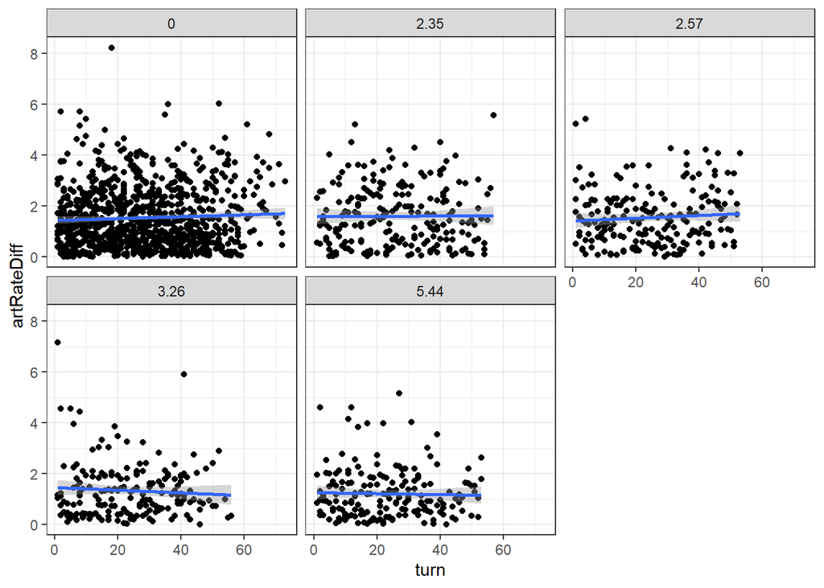

```r
ggplot(dat |> filter(role=="participant"), aes(turn, artRateDiff))+
  geom_point()+
  facet_wrap(~accentRating)+
  geom_smooth(method="lm")+
  theme_bw()
```